# VAR Predictability Benchmark

- Show All Code
- Hide All Code
- View Source

Meta Regression

Author

Affiliation

Björn S. Siepe

University of Marburg

Published

November 17, 2026

# 1 Preparation

We first load all relevant packages and data.

```r
library(here)
library(tibble)
library(dplyr)
library(brms)
library(pander)
library(parameters)
library(bayesplot)

seed <- 395013

# load data
df_meta <- readRDS(here::here("output", "meta", "combined.rds"))

# Make passes TRUE when the upstream combined results changed
# and direct renders reuse cached fits
# params only exists during knitr rendering, fall back to FALSE interactively
refit_models <- isTRUE(if (exists("params")) params$refit_models else FALSE)

# the cache file names outlive likelihood changes, so a stale cache would otherwise load silently
read_fit <- function(path, family) {
  fit <- readRDS(path)
  stopifnot(stats::family(fit)$family == family)
  fit
}

# the response as the model sees it, e.g. log(rel_mse) for the Student-t models
model_y <- function(fit) brms::standata(fit)$Y

# coord_cartesian zooms without dropping draws, so the densities still use all of them.
# widen: margin around the observed range, as a multiple of that range
ppc_density <- function(y, yrep, group = NULL, widen = 0.25) {
  limits <- range(y) + c(-1, 1) * widen * diff(range(y))
  p <- if (is.null(group)) {
    bayesplot::ppc_dens_overlay(y, yrep)
  } else {
    bayesplot::ppc_dens_overlay_grouped(y, yrep, group = group)
  }
  p + ggplot2::coord_cartesian(xlim = limits)
}

q01 <- function(x) stats::quantile(x, 0.01)
q05 <- function(x) stats::quantile(x, 0.05)
q95 <- function(x) stats::quantile(x, 0.95)
q99 <- function(x) stats::quantile(x, 0.99)

# log_y: compare on the log scale, for the lognormal S1 whose response is rel_mse itself
prior_check <- function(fit, log_y = FALSE) {
  y <- model_y(fit)
  yrep <- brms::posterior_predict(fit, ndraws = 50)
  if (log_y) {
    y <- log(y)
    yrep <- log(yrep)
  }
  ppc_density(y, yrep, widen = 1)
}

posterior_checks <- function(fit, log_y = FALSE) {
  y <- model_y(fit)
  yrep <- brms::posterior_predict(fit, ndraws = 500)
  if (log_y) {
    y <- log(y)
    yrep <- log(yrep)
  }
  group <- fit$data$model
  print(ppc_density(y, yrep[1:50, ], group = group))
  print(bayesplot::ppc_stat_2d(y, yrep, stat = c("q05", "q95")))
  print(bayesplot::ppc_stat_2d(y, yrep, stat = c("q01", "q99")))
  for (stat in c("q05", "q95")) {
    print(bayesplot::ppc_stat_grouped(y, yrep, group = group, stat = stat) +
            ggplot2::ggtitle(stat))
  }
  invisible(NULL)
}
```

All models are fitted with `refresh = 0` and `silent = 2`, so that the rendered report does not contain Stan’s compilation and sampling messages.

The predictive checks compare the observed response with responses simulated from the model, using each person’s and dataset’s estimated random effects. With a Student-t likelihood, a few simulated values are extreme, and a density plot would stretch its x-axis to include them, so that the bulk of the distribution is no longer visible. The density plots are therefore zoomed to the observed range plus a margin, without dropping any simulated values, and drawn separately per benchmark model.

As a density plot cannot show well whether a model reproduces the spread and the tails, each posterior check also compares quantiles of the simulated data with the observed ones:

- The 5% and 95% quantiles describe the spread of the bulk of the distribution. They are not affected by single extreme values.
- The 1% and 99% quantiles describe the tails. This is where a Student-t likelihood should differ from a lognormal one, if the data contain outliers.
- The 5% and 95% quantiles per benchmark model show whether a misfit comes from particular models, for example from the long right tail of the idiographic VAR.

The lognormal model S1 is checked on the log scale as well, so that its checks are comparable to those of the Student-t models. The checks of S4 are not directly comparable: on the raw scale, most of the spread of log MSE is between persons, and the person random effects absorb it.

We then need to create unique identifiers for each individual, ensuring that the same id number is not mistaken as the same person across different datasets. We do this by combining the dataset name and the person id.

```r
df_meta <- df_meta |>
  dplyr::mutate(unique_id = paste0(dataset_id, "_", id))
```

```r
# the mean model is the reference (rel_mse = 1 by construction), so it is not a row here
df_rel <- df_meta |>
  dplyr::filter(set == "oos", model != "mean", is.finite(rel_mse), rel_mse > 0) |>
  dplyr::mutate(model = droplevels(model))
```

```r
# rows without a defined relative MSE, by reason (reason_na from relative_mse() in 03)
df_meta |>
  dplyr::filter(set == "oos", model != "mean", !is.finite(rel_mse)) |>
  dplyr::count(model, reason_na) |>
  pander::pander(caption = "OOS person rows excluded from the relative MSE models.")
```

OOS person rows excluded from the relative MSE models.

| model | reason_na | n |
| --- | --- | --- |
| naive | zero_model | 289 |
| naive | zero_reference | 4 |
| trend | zero_reference | 4 |
| ri | zero_reference | 4 |
| ar | zero_model | 8 |
| ar | zero_reference | 4 |
| var | zero_model | 5 |
| var | zero_reference | 4 |
| lasso_var | zero_reference | 4 |
| ml_ar | zero_reference | 4 |
| ml_var | zero_reference | 4 |

# 2 Meta Regression for Relative MSE

## 2.1 Student-t Models

### 2.1.1 Fixed-Effect for Model, Random-Effect for Dataset (M1)

We now fit a simple meta regression model for the log relative MSE with a Student-t likelihood.

```r
model_path <- here::here("output", "analysis", "fit_relmse_m1.rds")

priors_rel <- c(
  prior(normal(0, 1), class = b),
  prior(exponential(2), class = sd),
  prior(normal(-1, 1), class = b, dpar = sigma)
)
# the brms default for nu, stated so that it is reported. the lognormal S1 has no nu
priors_t <- c(priors_rel, prior(gamma(2, 0.1), class = nu))

if (refit_models || !file.exists(model_path)) {
  fit_relmse_m1 <- brm(
    # no intercept: the mean model is the reference and already divided out of rel_mse,
    # so each coefficient is that model's location of log relative MSE
    bf(log(rel_mse) ~ 0 + model + (1 | dataset_id) + (1 | dataset_id:model) + (1 | unique_id),
       sigma ~ 0 + model),
    data = df_rel,
    family = student(),
    prior = priors_t,
    chains = 4,
    cores = 4,
    iter = 3000,
    warmup = 1000,
    seed = seed,
    refresh = 0,
    silent = 2
  )

  saveRDS(fit_relmse_m1, model_path)
} else {
  fit_relmse_m1 <- read_fit(model_path, "student")
}
```

These priors are:

```r
brms::prior_summary(fit_relmse_m1) |>
  dplyr::select(prior, class, coef, group) |>
  pander::pander(caption = "Priors for the Student-t meta regression model M1.")
```

Priors for the Student-t meta regression model M1.

| prior | class | coef | group |
| --- | --- | --- | --- |
| normal(0, 1) | b |  |  |
|  | b | modelar |  |
|  | b | modellasso_var |  |
|  | b | modelml_ar |  |
|  | b | modelml_var |  |
|  | b | modelnaive |  |
|  | b | modelri |  |
|  | b | modeltrend |  |
|  | b | modelvar |  |
| normal(-1, 1) | b |  |  |
|  | b | modelar |  |
|  | b | modellasso_var |  |
|  | b | modelml_ar |  |
|  | b | modelml_var |  |
|  | b | modelnaive |  |
|  | b | modelri |  |
|  | b | modeltrend |  |
|  | b | modelvar |  |
| gamma(2, 0.1) | nu |  |  |
| exponential(2) | sd |  |  |
|  | sd |  | dataset_id |
|  | sd | Intercept | dataset_id |
|  | sd |  | dataset_id:model |
|  | sd | Intercept | dataset_id:model |
|  | sd |  | unique_id |
|  | sd | Intercept | unique_id |

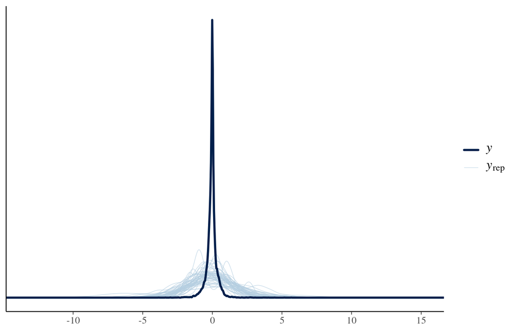

```r
model_path <- here::here("output", "analysis", "fit_relmse_m1_prior.rds")

if (refit_models || !file.exists(model_path)) {
  fit_relmse_m1_prior <- update(fit_relmse_m1, sample_prior = "only", seed = seed,
    refresh = 0, silent = 2)
  saveRDS(fit_relmse_m1_prior, model_path)
} else {
  fit_relmse_m1_prior <- read_fit(model_path, "student")
}

prior_check(fit_relmse_m1_prior)
```

Here’s the summary of the model:

```r
parameters::model_parameters(fit_relmse_m1, test = "pd")
```

```
# Fixed Effects

Parameter      |   Median |         95% CI |     pd |  Rhat | ESS (tail)
------------------------------------------------------------------------
modelnaive     |     0.23 | [ 0.17,  0.28] |   100% | 1.000 |       4479
modeltrend     | 3.66e-04 | [-0.05,  0.05] | 50.59% | 1.001 |       4476
modelri        | 1.84e-03 | [-0.05,  0.05] | 52.85% | 1.002 |       3186
modelar        |    -0.08 | [-0.13, -0.04] |   100% | 1.000 |       3397
modelvar       |     0.16 | [ 0.11,  0.21] |   100% | 1.000 |       4838
modellasso_var |    -0.02 | [-0.07,  0.03] | 82.39% | 1.001 |       3656
modelml_ar     |    -0.09 | [-0.14, -0.04] |   100% | 1.002 |       3624
modelml_var    |    -0.08 | [-0.13, -0.03] | 99.95% | 1.001 |       3550

# sigma Parameters

Parameter      | Median |         95% CI |   pd |  Rhat | ESS (tail)
--------------------------------------------------------------------
modelnaive     |  -1.31 | [-1.38, -1.25] | 100% | 1.001 |       5454
modeltrend     |  -1.59 | [-1.65, -1.53] | 100% | 1.000 |       6379
modelri        |  -4.04 | [-4.12, -3.96] | 100% | 1.000 |       6529
modelar        |  -2.22 | [-2.28, -2.15] | 100% | 1.000 |       5929
modelvar       |  -1.58 | [-1.65, -1.52] | 100% | 1.001 |       5587
modellasso_var |  -2.28 | [-2.35, -2.21] | 100% | 1.000 |       5532
modelml_ar     |  -2.26 | [-2.33, -2.20] | 100% | 1.000 |       5949
modelml_var    |  -1.99 | [-2.06, -1.93] | 100% | 1.000 |       5852
```

Here’s a traceplot of some main parameters:

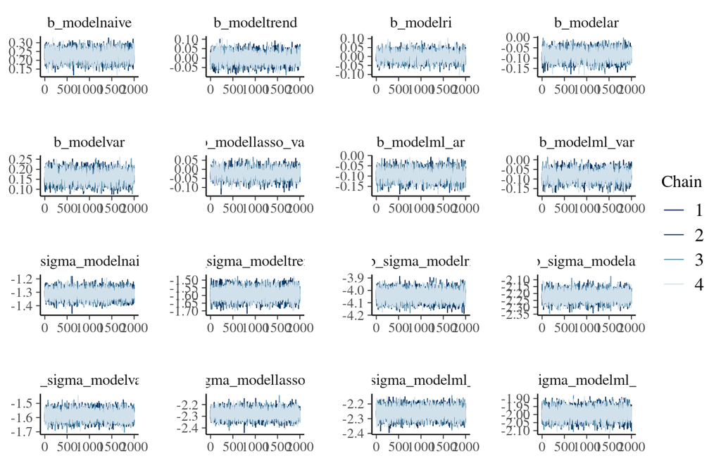

```r
bayesplot::mcmc_trace(fit_relmse_m1, regex_pars = "^b_")
```

Here are the posterior predictive checks of the model:

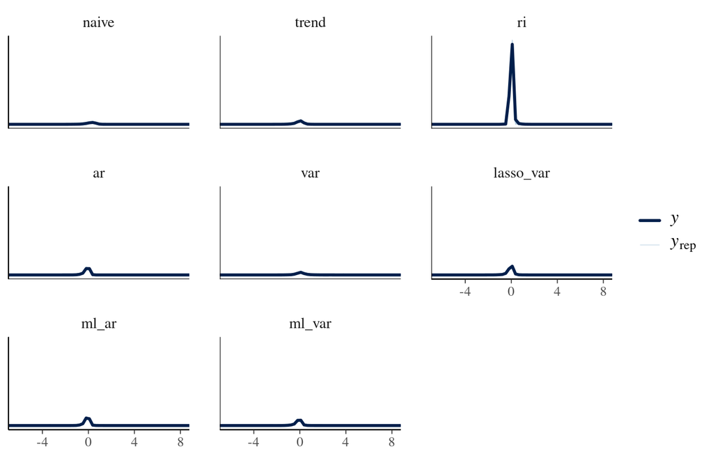

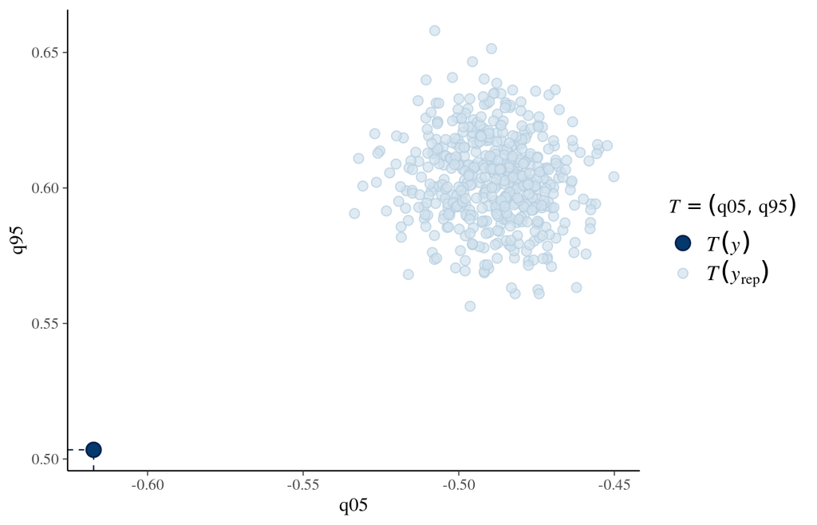

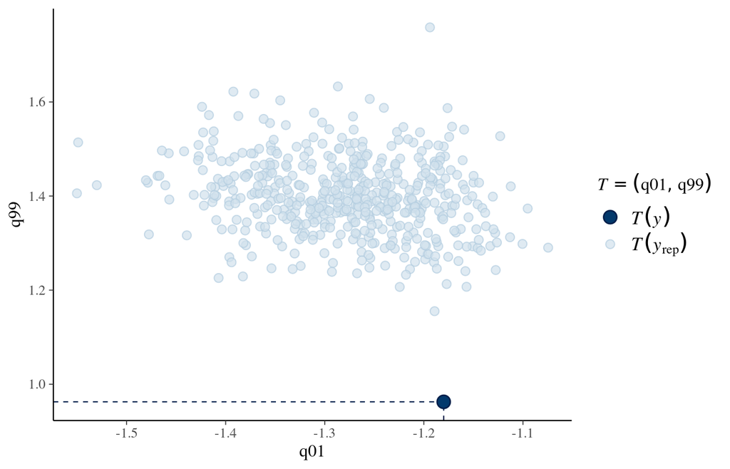

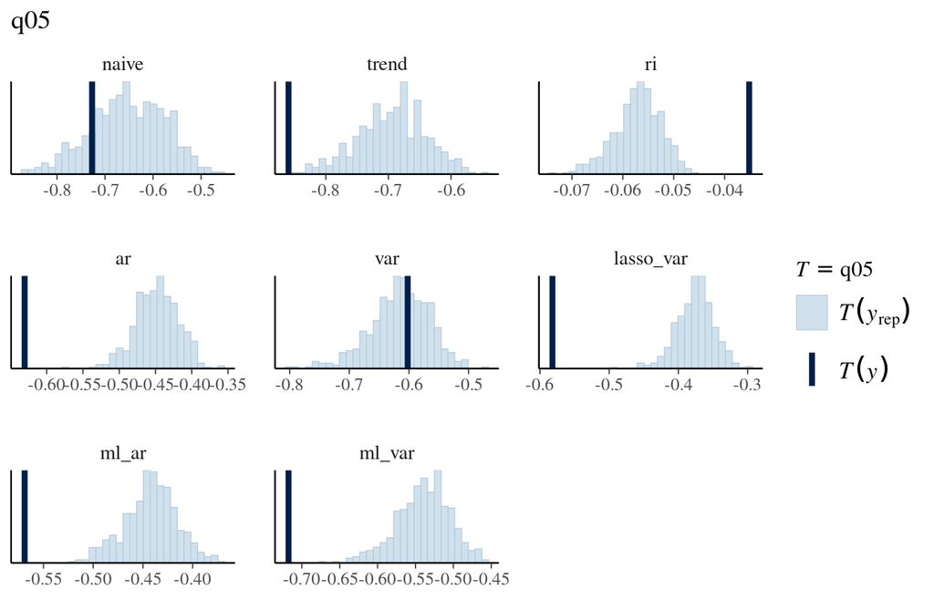

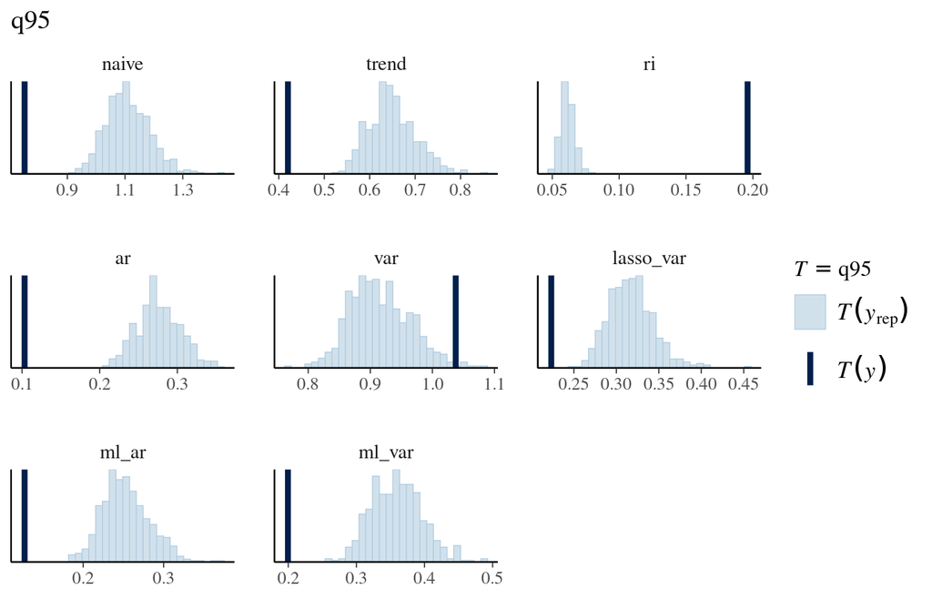

```r
posterior_checks(fit_relmse_m1)
```

### 2.1.2 M1 with Dataset-Specific Scales (M1b)

In M1, the residual scale differs only between benchmark models. Each model’s errors are thus assumed to scatter equally widely in every dataset. The item-level results suggest otherwise: the idiographic VAR, for example, scatters much more in datasets with few observations per parameter. A Student-t likelihood with very small degrees of freedom ν can absorb such differences by being both very peaked and very wide. M1b therefore adds a random intercept for each combination of dataset and model to the log residual scale, so that the scales are partially pooled in the same way as the locations. The location part and all other priors are the same as in M1. The standard deviation of the new random effect gets the same prior as the other random-effect standard deviations.

If the small ν in M1 reflects such differences in scale, ν should be larger in M1b, and the predictive checks per benchmark model should fit better. If the location estimates of M1 and M1b agree, our results do not depend on how the scale is modelled.

```r
model_path <- here::here("output", "analysis", "fit_relmse_m1b.rds")

priors_t_scale <- c(priors_t, prior(exponential(2), class = sd, dpar = sigma))

if (refit_models || !file.exists(model_path)) {
  fit_relmse_m1b <- brm(
    bf(log(rel_mse) ~ 0 + model + (1 | dataset_id) + (1 | dataset_id:model) + (1 | unique_id),
       sigma ~ 0 + model + (1 | dataset_id:model)),
    data = df_rel,
    family = student(),
    prior = priors_t_scale,
    chains = 4,
    cores = 4,
    iter = 3000,
    warmup = 1000,
    seed = seed,
    refresh = 0,
    silent = 2
  )

  saveRDS(fit_relmse_m1b, model_path)
} else {
  fit_relmse_m1b <- read_fit(model_path, "student")
}
```

[output not shown]

```r
parameters::model_parameters(fit_relmse_m1b, test = "pd")
```

```
# Fixed Effects

Parameter      |    Median |         95% CI |     pd |  Rhat | ESS (tail)
-------------------------------------------------------------------------
modelnaive     |      0.23 | [ 0.17,  0.28] |   100% | 1.001 |       3696
modeltrend     | -3.66e-03 | [-0.05,  0.05] | 56.09% | 1.003 |       2865
modelri        |  7.43e-03 | [-0.04,  0.05] | 62.01% | 1.002 |       2687
modelar        |     -0.09 | [-0.14, -0.04] |   100% | 1.001 |       3199
modelvar       |      0.15 | [ 0.09,  0.20] |   100% | 1.004 |       3239
modellasso_var |     -0.03 | [-0.08,  0.02] | 89.40% | 1.000 |       2998
modelml_ar     |     -0.10 | [-0.15, -0.05] |   100% | 1.001 |       2719
modelml_var    |     -0.09 | [-0.13, -0.04] | 99.96% | 1.001 |       3265

# sigma Parameters

Parameter      | Median |         95% CI |   pd |  Rhat | ESS (tail)
--------------------------------------------------------------------
modelnaive     |  -1.31 | [-1.51, -1.11] | 100% | 1.001 |       3083
modeltrend     |  -1.58 | [-1.78, -1.38] | 100% | 1.009 |       2525
modelri        |  -3.77 | [-3.96, -3.57] | 100% | 1.001 |       3294
modelar        |  -2.17 | [-2.37, -1.97] | 100% | 1.002 |       2877
modelvar       |  -1.47 | [-1.67, -1.28] | 100% | 1.001 |       3478
modellasso_var |  -2.20 | [-2.41, -2.00] | 100% | 1.001 |       2426
modelml_ar     |  -2.22 | [-2.42, -2.02] | 100% | 1.002 |       2521
modelml_var    |  -1.93 | [-2.12, -1.72] | 100% | 1.002 |       2818
```

Posterior predictive checks of M1b:

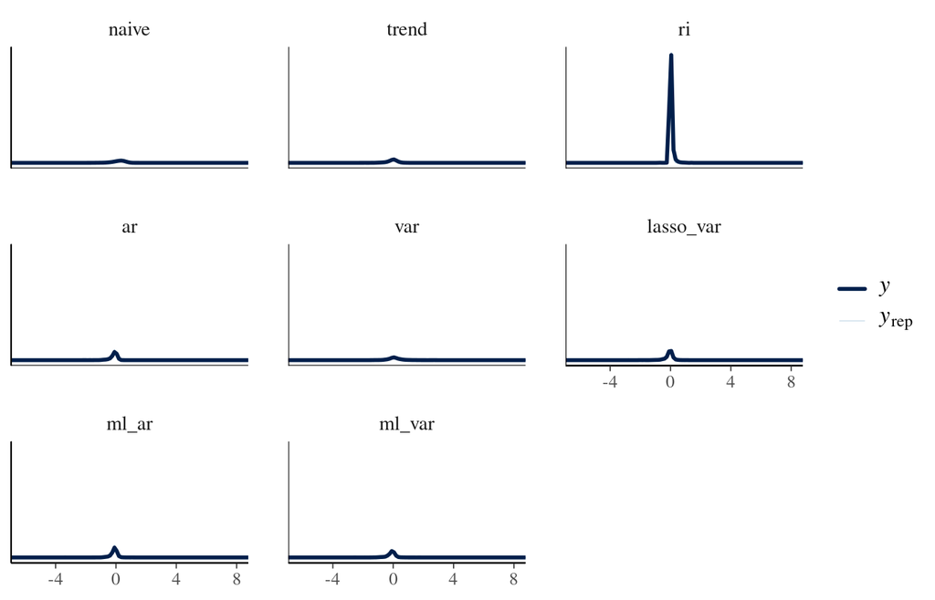

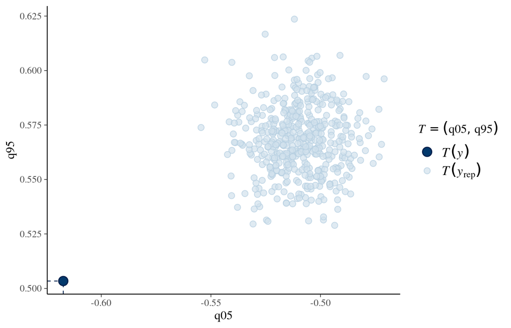

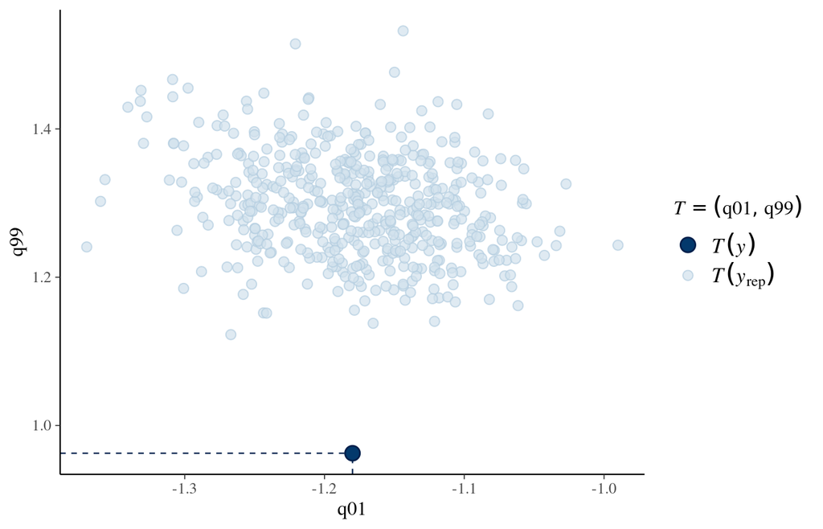

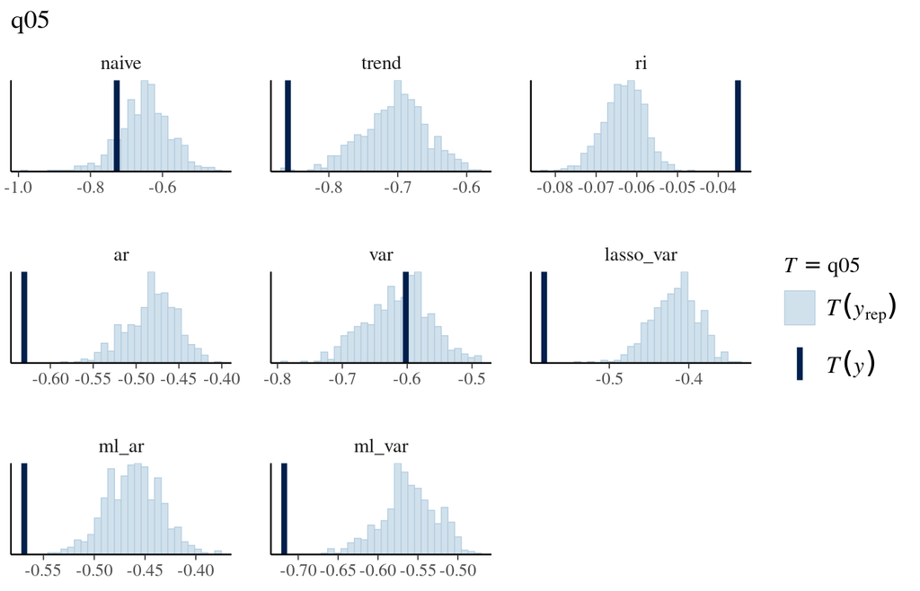

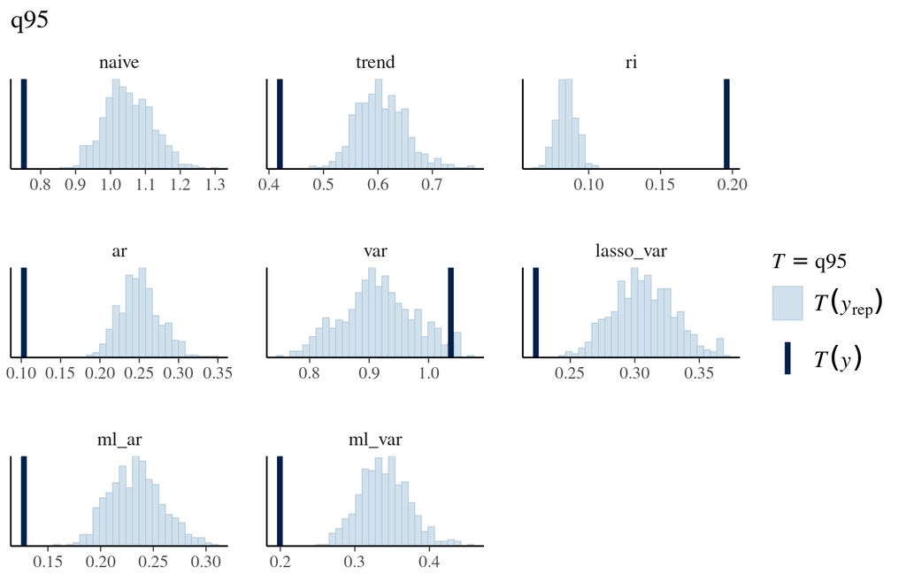

```r
posterior_checks(fit_relmse_m1b)
```

The next table compares ν between M1 and M1b, and then the location estimates of each benchmark model, as relMSE relative to the mean model. Both are posterior medians with 95% credible intervals.

```r
nu_summary <- function(fit) {
  nu <- brms::as_draws_df(fit, variable = "nu")$nu
  sprintf("%.2f [%.2f, %.2f]", stats::median(nu), stats::quantile(nu, 0.025),
          stats::quantile(nu, 0.975))
}

tibble::tibble(model = c("M1", "M1b"),
               nu = c(nu_summary(fit_relmse_m1), nu_summary(fit_relmse_m1b))) |>
  pander::pander(caption = "Degrees of freedom of the Student-t likelihood.")
```

Degrees of freedom of the Student-t likelihood.

| model | nu |
| --- | --- |
| M1 | 1.74 [1.66, 1.83] |
| M1b | 2.12 [2.01, 2.24] |

```r
location_summary <- function(fit) {
  location <- brms::fixef(fit, robust = TRUE)
  location <- location[grepl("^model", rownames(location)), , drop = FALSE]
  tibble::tibble(model = sub("^model", "", rownames(location)),
                 rel_mse = sprintf("%.2f [%.2f, %.2f]", exp(location[, "Estimate"]),
                                   exp(location[, "Q2.5"]), exp(location[, "Q97.5"])))
}

dplyr::left_join(location_summary(fit_relmse_m1), location_summary(fit_relmse_m1b),
                 by = "model", suffix = c("_m1", "_m1b")) |>
  pander::pander(caption = "Population-level relMSE relative to the mean model, M1 vs. M1b.")
```

Population-level relMSE relative to the mean model, M1 vs. M1b.

| model | rel_mse_m1 | rel_mse_m1b |
| --- | --- | --- |
| naive | 1.26 [1.19, 1.33] | 1.26 [1.19, 1.33] |
| trend | 1.00 [0.95, 1.05] | 1.00 [0.95, 1.05] |
| ri | 1.00 [0.96, 1.05] | 1.01 [0.96, 1.06] |
| ar | 0.92 [0.87, 0.97] | 0.91 [0.87, 0.96] |
| var | 1.17 [1.12, 1.24] | 1.16 [1.10, 1.22] |
| lasso_var | 0.98 [0.93, 1.03] | 0.97 [0.92, 1.02] |
| ml_ar | 0.91 [0.87, 0.96] | 0.91 [0.86, 0.95] |
| ml_var | 0.92 [0.87, 0.97] | 0.92 [0.87, 0.96] |

### 2.1.3 M1 + Training Length by Model (M2)

```r
source(here::here("scripts", "engine", "relative.R"))
features <- readRDS(here::here("output", "analysis", "features.rds"))

# log training length split into the dataset mean (between) and the person's deviation from it (within)
train_length <- features$person |>
  dplyr::mutate(log_n = log(n_train_first)) |>
  split_between_within(log_n, dataset_id) |>
  dplyr::select(dataset_id, id, log_n_between, log_n_within)

df_rel <- dplyr::left_join(df_rel, train_length, by = c("dataset_id", "id"))
stopifnot(!anyNA(df_rel$log_n_within))
```

```r
model_path <- here::here("output", "analysis", "fit_relmse_m2.rds")

if (refit_models || !file.exists(model_path)) {
  fit_relmse_m2 <- brm(
    # one between and one within slope per model
    bf(log(rel_mse) ~ 0 + model + model:log_n_between + model:log_n_within +
         (1 | dataset_id) + (1 | dataset_id:model) + (1 | unique_id),
       sigma ~ 0 + model),
    data = df_rel,
    family = student(),
    prior = priors_t,
    chains = 4,
    cores = 4,
    iter = 3000,
    warmup = 1000,
    seed = seed,
    refresh = 0,
    silent = 2
  )

  saveRDS(fit_relmse_m2, model_path)
} else {
  fit_relmse_m2 <- read_fit(model_path, "student")
}
```

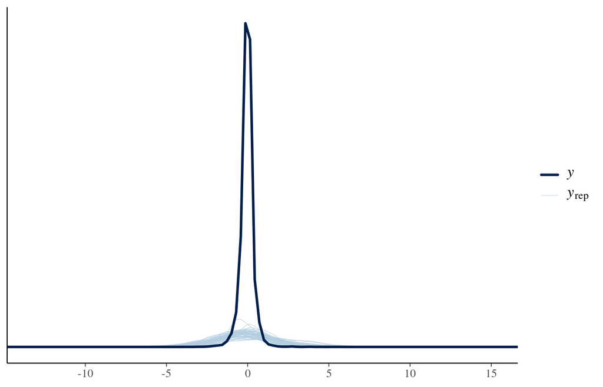

```r
model_path <- here::here("output", "analysis", "fit_relmse_m2_prior.rds")

if (refit_models || !file.exists(model_path)) {
  fit_relmse_m2_prior <- update(fit_relmse_m2, sample_prior = "only", seed = seed,
    refresh = 0, silent = 2)
  saveRDS(fit_relmse_m2_prior, model_path)
} else {
  fit_relmse_m2_prior <- read_fit(model_path, "student")
}

prior_check(fit_relmse_m2_prior)
```

```r
parameters::model_parameters(fit_relmse_m2, test = "pd")
```

```
# Fixed Effects

Parameter                    |   Median |         95% CI |     pd |  Rhat | ESS (tail)
--------------------------------------------------------------------------------------
modelnaive                   |     0.23 | [ 0.18,  0.28] |   100% | 1.001 |       4645
modeltrend                   | 1.41e-03 | [-0.04,  0.05] | 52.52% | 1.002 |       4055
modelri                      | 2.71e-03 | [-0.04,  0.04] | 55.44% | 1.005 |       3001
modelar                      |    -0.09 | [-0.13, -0.05] |   100% | 1.001 |       3890
modelvar                     |     0.18 | [ 0.13,  0.22] |   100% | 1.002 |       4251
modellasso_var               |    -0.03 | [-0.07,  0.02] | 87.90% | 1.002 |       3388
modelml_ar                   |    -0.10 | [-0.14, -0.05] |   100% | 1.002 |       3563
modelml_var                  |    -0.08 | [-0.13, -0.04] |   100% | 1.001 |       3688
modelnaive:log_n_between     |    -0.03 | [-0.09,  0.04] | 78.10% | 1.001 |       4048
modeltrend:log_n_between     |    -0.09 | [-0.15, -0.03] | 99.90% | 1.001 |       4654
modelri:log_n_between        | 2.37e-03 | [-0.06,  0.06] | 53.31% | 1.003 |       3725
modelar:log_n_between        |    -0.04 | [-0.09,  0.02] | 88.59% | 1.001 |       4099
modelvar:log_n_between       |    -0.22 | [-0.28, -0.15] |   100% | 1.001 |       4601
modellasso_var:log_n_between |    -0.06 | [-0.11,  0.00] | 96.70% | 1.002 |       3865
modelml_ar:log_n_between     |    -0.02 | [-0.08,  0.04] | 74.10% | 1.000 |       3562
modelml_var:log_n_between    |    -0.03 | [-0.09,  0.03] | 85.44% | 1.000 |       3791
modelnaive:log_n_within      |    -0.08 | [-0.16,  0.01] | 95.09% | 1.001 |       5213
modeltrend:log_n_within      |    -0.13 | [-0.19, -0.07] |   100% | 1.002 |       5910
modelri:log_n_within         | 9.73e-04 | [ 0.00,  0.01] | 65.36% | 1.001 |       5681
modelar:log_n_within         |    -0.09 | [-0.12, -0.06] |   100% | 1.001 |       5668
modelvar:log_n_within        |    -0.27 | [-0.32, -0.21] |   100% | 1.001 |       5347
modellasso_var:log_n_within  |    -0.10 | [-0.13, -0.07] |   100% | 1.000 |       5889
modelml_ar:log_n_within      |    -0.06 | [-0.09, -0.03] | 99.99% | 1.001 |       6093
modelml_var:log_n_within     |    -0.06 | [-0.10, -0.02] | 99.94% | 1.002 |       5280

# sigma Parameters

Parameter      | Median |         95% CI |   pd |  Rhat | ESS (tail)
--------------------------------------------------------------------
modelnaive     |  -1.31 | [-1.38, -1.24] | 100% | 1.001 |       5835
modeltrend     |  -1.60 | [-1.66, -1.53] | 100% | 1.000 |       6273
modelri        |  -4.04 | [-4.12, -3.96] | 100% | 1.000 |       6290
modelar        |  -2.23 | [-2.29, -2.17] | 100% | 1.000 |       6435
modelvar       |  -1.61 | [-1.68, -1.55] | 100% | 1.001 |       5842
modellasso_var |  -2.29 | [-2.36, -2.22] | 100% | 1.000 |       5857
modelml_ar     |  -2.27 | [-2.33, -2.20] | 100% | 1.001 |       6069
modelml_var    |  -2.00 | [-2.06, -1.94] | 100% | 1.000 |       6063
```

Posterior predictive checks of M2:

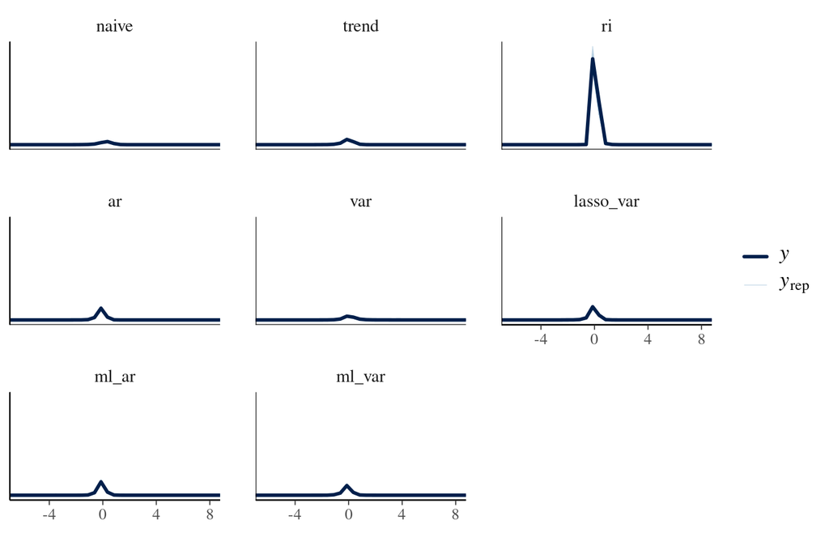

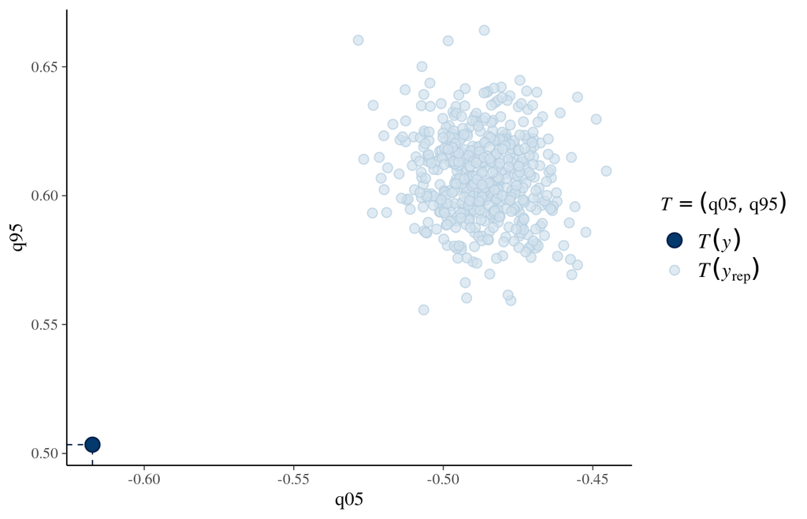

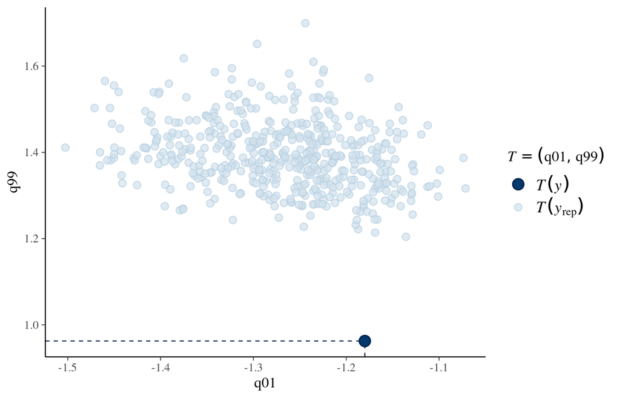

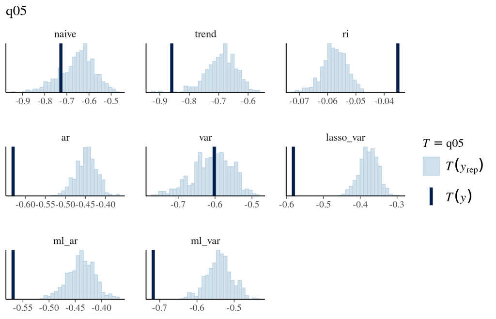

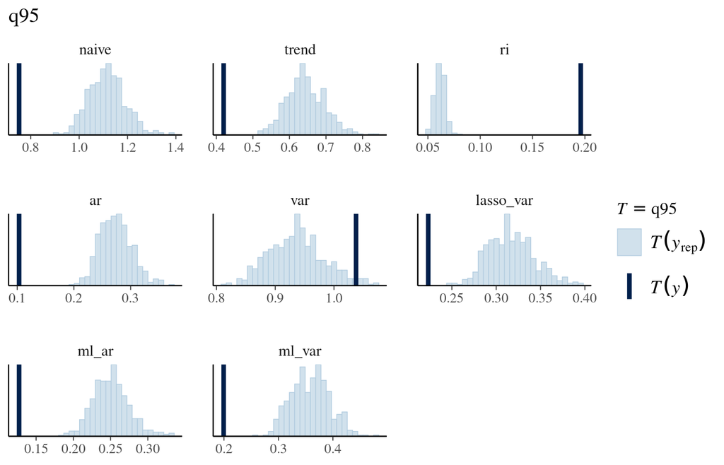

```r
posterior_checks(fit_relmse_m2)
```

### 2.1.4 M2 + Autocorrelation by Model (M3)

```r
# mean lag-1 autocorrelation of the items in the training window, split like training length
autocorrelation <- features$person |>
  dplyr::mutate(rho1 = rho1_train_mean) |>
  split_between_within(rho1, dataset_id) |>
  dplyr::select(dataset_id, id, rho1_between, rho1_within)

# rho1 is undefined for persons without observed lag pairs in the training window
df_m3 <- df_rel |>
  dplyr::left_join(autocorrelation, by = c("dataset_id", "id")) |>
  dplyr::filter(!is.na(rho1_within))
```

```r
model_path <- here::here("output", "analysis", "fit_relmse_m3.rds")

if (refit_models || !file.exists(model_path)) {
  fit_relmse_m3 <- brm(
    bf(log(rel_mse) ~ 0 + model + model:log_n_between + model:log_n_within +
         model:rho1_between + model:rho1_within +
         (1 | dataset_id) + (1 | dataset_id:model) + (1 | unique_id),
       sigma ~ 0 + model),
    data = df_m3,
    family = student(),
    prior = priors_t,
    chains = 4,
    cores = 4,
    iter = 3000,
    warmup = 1000,
    seed = seed,
    refresh = 0,
    silent = 2
  )

  saveRDS(fit_relmse_m3, model_path)
} else {
  fit_relmse_m3 <- read_fit(model_path, "student")
}
```

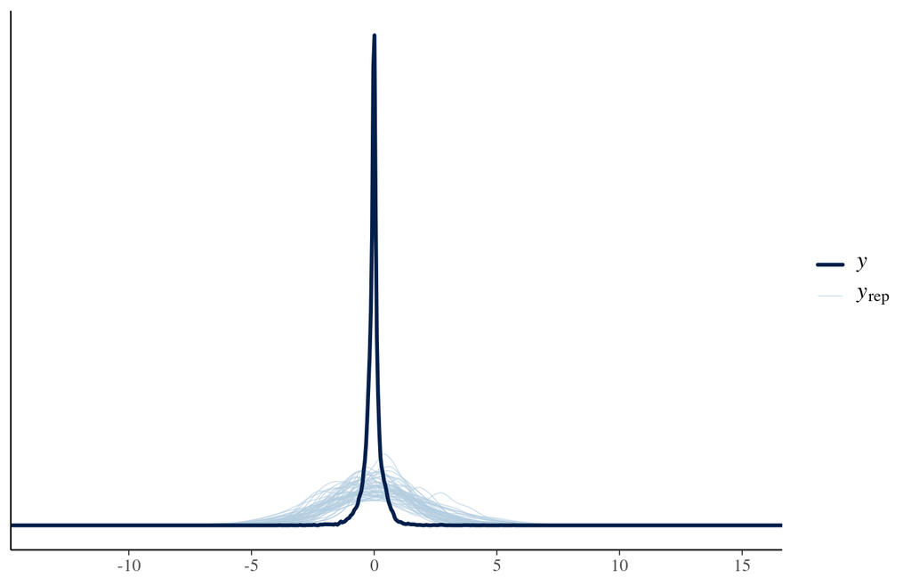

```r
model_path <- here::here("output", "analysis", "fit_relmse_m3_prior.rds")

if (refit_models || !file.exists(model_path)) {
  fit_relmse_m3_prior <- update(fit_relmse_m3, sample_prior = "only", seed = seed,
    refresh = 0, silent = 2)
  saveRDS(fit_relmse_m3_prior, model_path)
} else {
  fit_relmse_m3_prior <- read_fit(model_path, "student")
}

prior_check(fit_relmse_m3_prior)
```

```r
parameters::model_parameters(fit_relmse_m3, test = "pd")
```

```
# Fixed Effects

Parameter                    |    Median |         95% CI |     pd |  Rhat | ESS (tail)
---------------------------------------------------------------------------------------
modelnaive                   |      0.21 | [ 0.16,  0.25] |   100% | 1.001 |       6100
modeltrend                   |  2.66e-03 | [-0.04,  0.05] | 54.69% | 1.001 |       4559
modelri                      |  3.24e-03 | [-0.04,  0.04] | 56.49% | 1.001 |       3585
modelar                      |     -0.11 | [-0.15, -0.07] |   100% | 1.002 |       3887
modelvar                     |      0.17 | [ 0.12,  0.21] |   100% | 1.001 |       4636
modellasso_var               |     -0.04 | [-0.08,  0.00] | 97.36% | 1.002 |       4189
modelml_ar                   |     -0.11 | [-0.15, -0.07] |   100% | 1.000 |       4144
modelml_var                  |     -0.09 | [-0.13, -0.05] |   100% | 1.003 |       3801
modelnaive:log_n_between     |      0.05 | [-0.03,  0.13] | 89.78% | 1.000 |       5658
modeltrend:log_n_between     |     -0.10 | [-0.17, -0.03] | 99.76% | 1.001 |       4235
modelri:log_n_between        | -6.28e-03 | [-0.07,  0.06] | 57.67% | 1.001 |       3932
modelar:log_n_between        | -4.16e-04 | [-0.06,  0.06] | 50.49% | 1.001 |       4140
modelvar:log_n_between       |     -0.22 | [-0.29, -0.15] |   100% | 1.001 |       4552
modellasso_var:log_n_between |     -0.04 | [-0.11,  0.03] | 88.56% | 1.001 |       4307
modelml_ar:log_n_between     |  1.57e-03 | [-0.06,  0.07] | 52.24% | 1.001 |       4577
modelml_var:log_n_between    |     -0.02 | [-0.08,  0.05] | 72.30% | 1.000 |       3667
modelnaive:log_n_within      | -5.50e-03 | [-0.09,  0.08] | 55.01% | 1.000 |       6081
modeltrend:log_n_within      |     -0.13 | [-0.19, -0.08] |   100% | 1.000 |       6349
modelri:log_n_within         |  9.59e-04 | [ 0.00,  0.01] | 63.84% | 1.000 |       6209
modelar:log_n_within         |     -0.06 | [-0.09, -0.03] |   100% | 1.002 |       5896
modelvar:log_n_within        |     -0.23 | [-0.28, -0.17] |   100% | 1.001 |       6130
modellasso_var:log_n_within  |     -0.09 | [-0.12, -0.06] |   100% | 1.000 |       5641
modelml_ar:log_n_within      |     -0.02 | [-0.05,  0.01] | 92.06% | 1.001 |       5526
modelml_var:log_n_within     |     -0.02 | [-0.06,  0.02] | 80.84% | 1.001 |       5413
modelnaive:rho1_between      |     -1.43 | [-2.19, -0.63] | 99.95% | 1.001 |       5665
modeltrend:rho1_between      |     -0.01 | [-0.71,  0.68] | 51.55% | 1.002 |       4449
modelri:rho1_between         |      0.17 | [-0.46,  0.80] | 70.05% | 1.001 |       4364
modelar:rho1_between         |     -0.68 | [-1.33,  0.00] | 97.38% | 1.001 |       4364
modelvar:rho1_between        |     -0.24 | [-0.95,  0.46] | 76.20% | 1.000 |       4843
modellasso_var:rho1_between  |     -0.47 | [-1.12,  0.18] | 91.74% | 1.001 |       3703
modelml_ar:rho1_between      |     -0.56 | [-1.23,  0.09] | 95.40% | 1.000 |       4597
modelml_var:rho1_between     |     -0.45 | [-1.11,  0.21] | 90.65% | 1.000 |       4381
modelnaive:rho1_within       |     -0.72 | [-0.88, -0.55] |   100% | 1.000 |       5549
modeltrend:rho1_within       |      0.04 | [-0.06,  0.14] | 77.89% | 1.001 |       5400
modelri:rho1_within          | -9.71e-04 | [-0.01,  0.01] | 58.43% | 1.002 |       5027
modelar:rho1_within          |     -0.47 | [-0.53, -0.41] |   100% | 1.000 |       5752
modelvar:rho1_within         |     -0.61 | [-0.73, -0.50] |   100% | 1.001 |       5329
modellasso_var:rho1_within   |     -0.36 | [-0.42, -0.30] |   100% | 1.000 |       5372
modelml_ar:rho1_within       |     -0.38 | [-0.43, -0.32] |   100% | 1.001 |       6026
modelml_var:rho1_within      |     -0.42 | [-0.49, -0.35] |   100% | 1.000 |       5603

# sigma Parameters

Parameter      | Median |         95% CI |   pd |  Rhat | ESS (tail)
--------------------------------------------------------------------
modelnaive     |  -1.33 | [-1.40, -1.27] | 100% | 1.000 |       5968
modeltrend     |  -1.58 | [-1.64, -1.52] | 100% | 1.000 |       5864
modelri        |  -4.00 | [-4.09, -3.92] | 100% | 1.001 |       3045
modelar        |  -2.28 | [-2.35, -2.22] | 100% | 1.000 |       5725
modelvar       |  -1.63 | [-1.70, -1.57] | 100% | 1.000 |       6168
modellasso_var |  -2.29 | [-2.36, -2.23] | 100% | 1.000 |       6518
modelml_ar     |  -2.30 | [-2.37, -2.24] | 100% | 1.001 |       5869
modelml_var    |  -2.02 | [-2.08, -1.96] | 100% | 1.001 |       5980
```

Posterior predictive checks of M3:

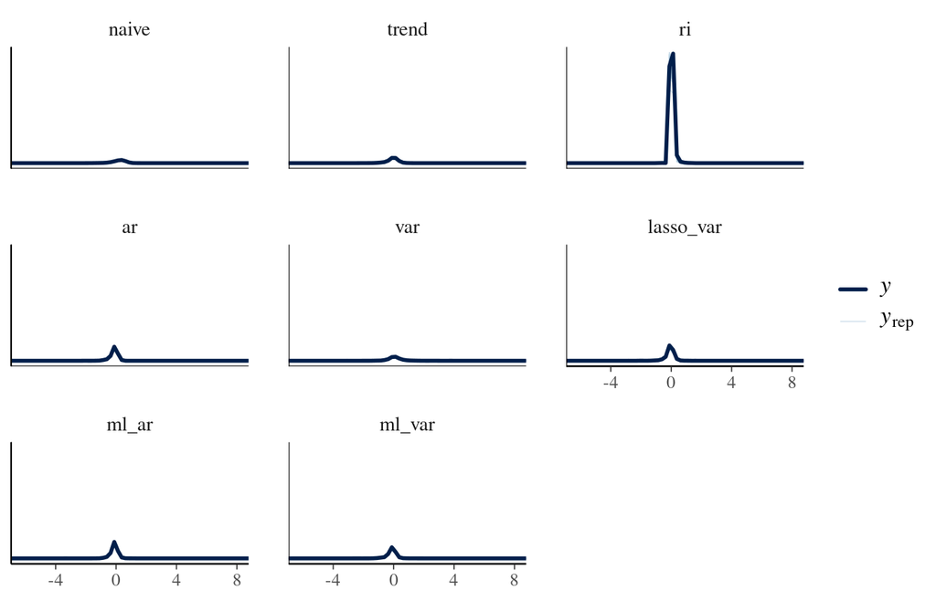

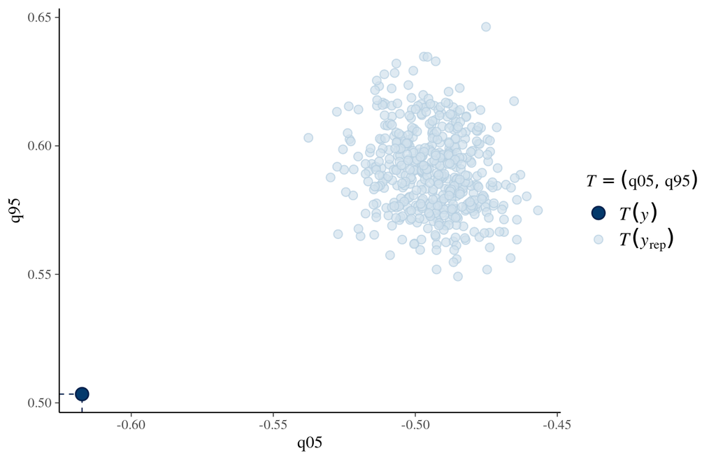

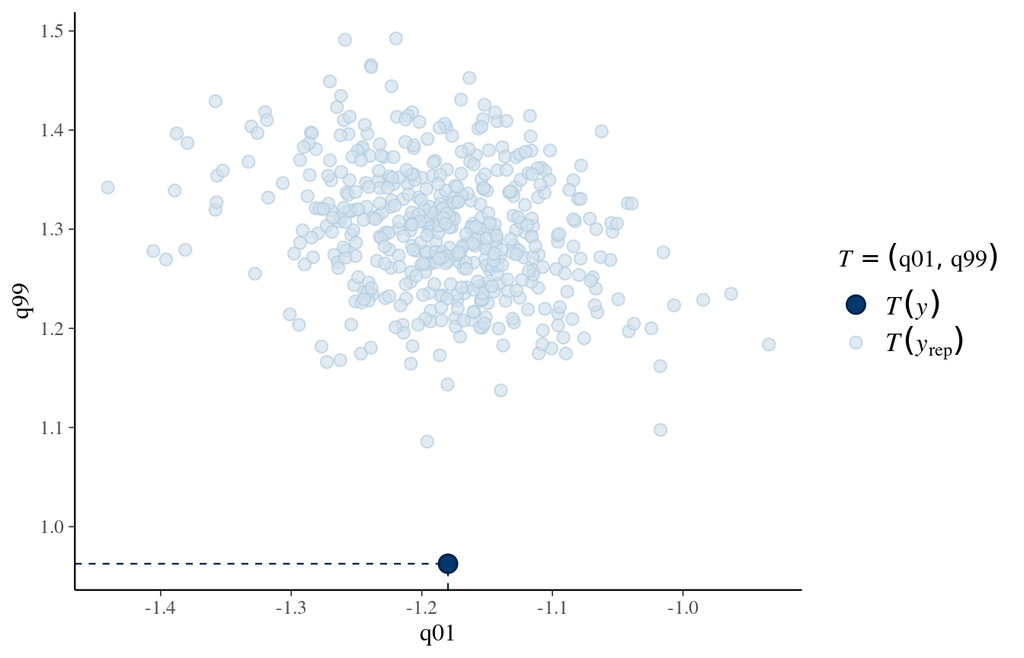

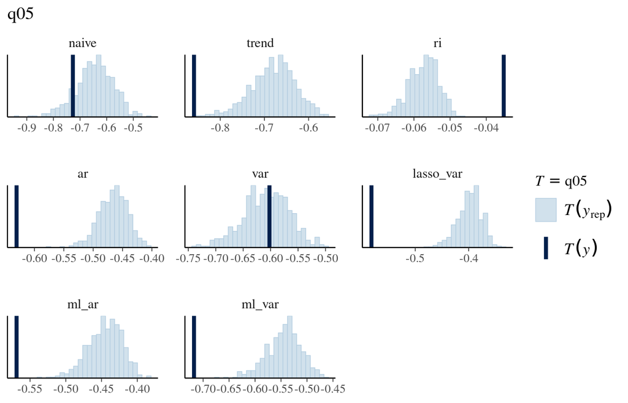

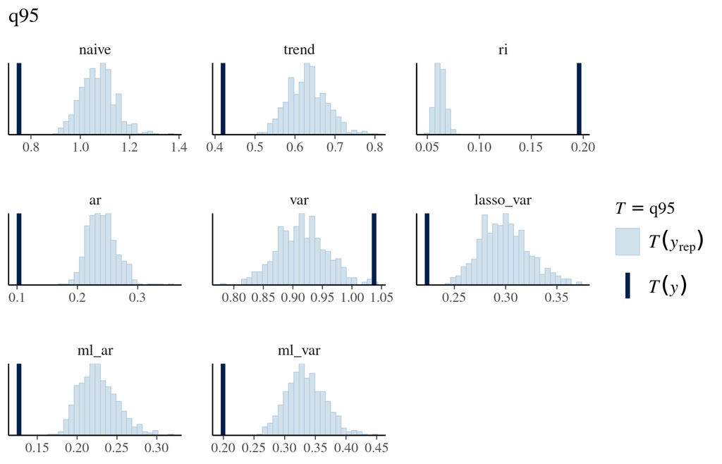

```r
posterior_checks(fit_relmse_m3)
```

# 3 Sensitivity Analyses

## 3.1 Log-Normal Likelihood (S1)

```r
model_path <- here::here("output", "analysis", "fit_relmse_s1.rds")

if (refit_models || !file.exists(model_path)) {
  fit_relmse_s1 <- brm(
    bf(rel_mse ~ 0 + model + (1 | dataset_id) + (1 | dataset_id:model) + (1 | unique_id),
       sigma ~ 0 + model),
    data = df_rel,
    family = lognormal(),
    prior = priors_rel,
    chains = 4,
    cores = 4,
    iter = 3000,
    warmup = 1000,
    seed = seed,
    refresh = 0,
    silent = 2
  )

  saveRDS(fit_relmse_s1, model_path)
} else {
  fit_relmse_s1 <- read_fit(model_path, "lognormal")
}
```

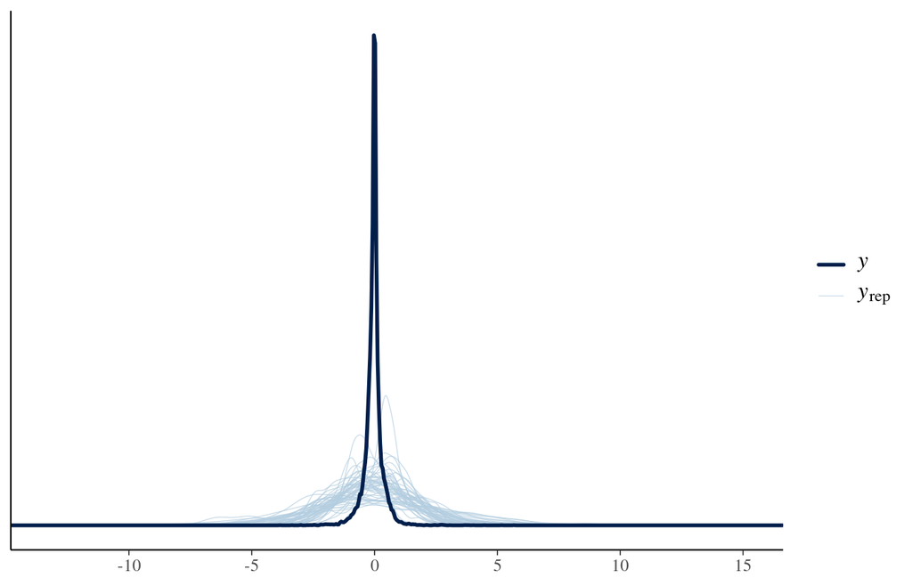

```r
model_path <- here::here("output", "analysis", "fit_relmse_s1_prior.rds")

if (refit_models || !file.exists(model_path)) {
  fit_relmse_s1_prior <- update(fit_relmse_s1, sample_prior = "only", seed = seed,
    refresh = 0, silent = 2)
  saveRDS(fit_relmse_s1_prior, model_path)
} else {
  fit_relmse_s1_prior <- read_fit(model_path, "lognormal")
}

prior_check(fit_relmse_s1_prior, log_y = TRUE)
```

```r
parameters::model_parameters(fit_relmse_s1, test = "pd")
```

```
# Fixed Effects

Parameter      | Median |         95% CI |     pd |  Rhat | ESS (tail)
----------------------------------------------------------------------
modelnaive     |   0.15 | [ 0.07,  0.24] | 99.96% | 1.001 |       2486
modeltrend     |  -0.05 | [-0.14,  0.02] | 91.06% | 1.003 |       2636
modelri        |   0.03 | [-0.05,  0.11] | 80.24% | 1.002 |       2230
modelar        |  -0.15 | [-0.22, -0.07] |   100% | 1.004 |       2504
modelvar       |   0.19 | [ 0.11,  0.28] |   100% | 1.002 |       2248
modellasso_var |  -0.08 | [-0.15,  0.00] | 97.32% | 1.001 |       2240
modelml_ar     |  -0.13 | [-0.21, -0.05] | 99.91% | 1.002 |       2265
modelml_var    |  -0.11 | [-0.19, -0.04] | 99.72% | 1.002 |       2404

# sigma Parameters

Parameter      | Median |         95% CI |   pd |  Rhat | ESS (tail)
--------------------------------------------------------------------
modelnaive     |  -1.07 | [-1.11, -1.03] | 100% | 1.001 |       5929
modeltrend     |  -0.95 | [-0.99, -0.91] | 100% | 1.000 |       6203
modelri        |  -1.55 | [-1.59, -1.51] | 100% | 1.000 |       6065
modelar        |  -2.09 | [-2.13, -2.04] | 100% | 1.000 |       5578
modelvar       |  -1.00 | [-1.04, -0.96] | 100% | 1.000 |       5756
modellasso_var |  -1.76 | [-1.80, -1.72] | 100% | 1.000 |       4784
modelml_ar     |  -2.94 | [-3.07, -2.84] | 100% | 1.004 |       1921
modelml_var    |  -2.12 | [-2.16, -2.08] | 100% | 1.000 |       5880
```

Posterior predictive checks of S1, on the log scale. Compared with the checks of M1, they show whether the lognormal likelihood reproduces the spread and the tails of log relative MSE as well as the Student-t likelihood does.

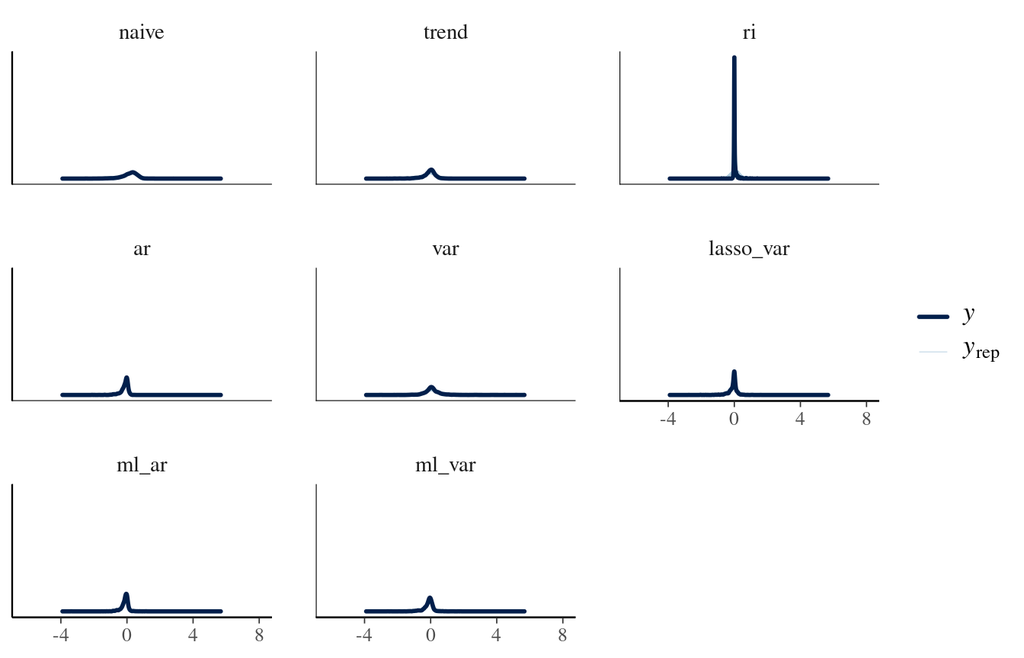

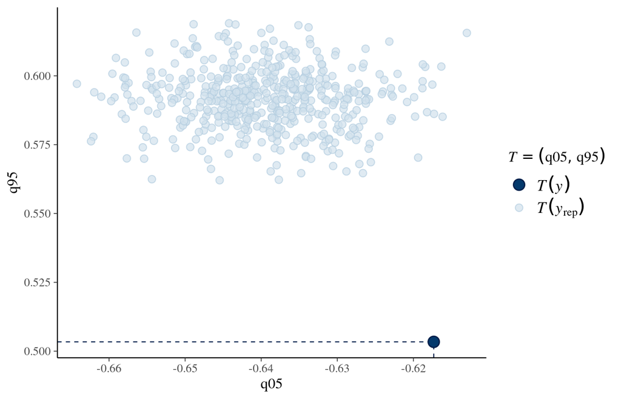

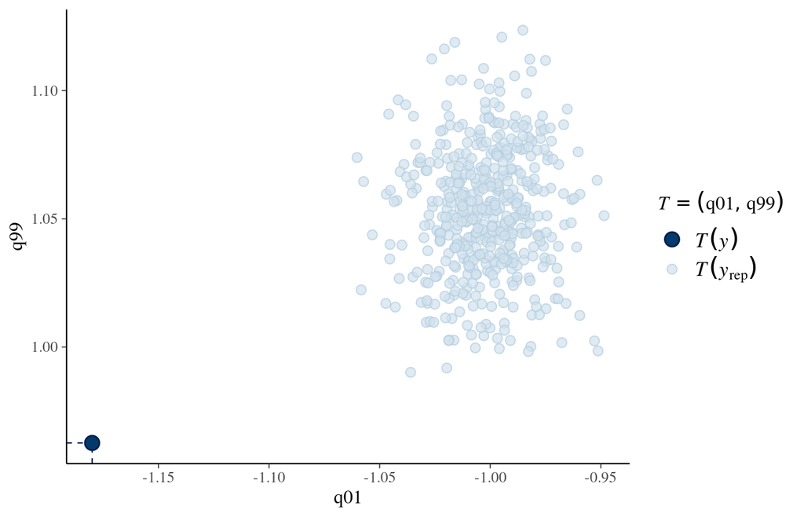

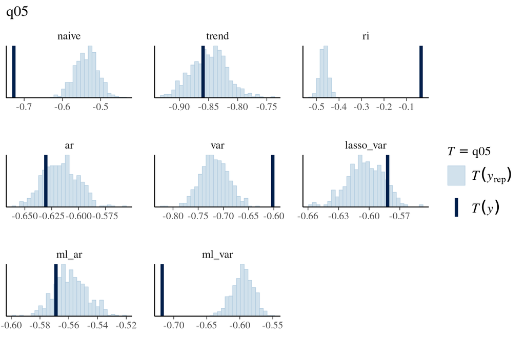

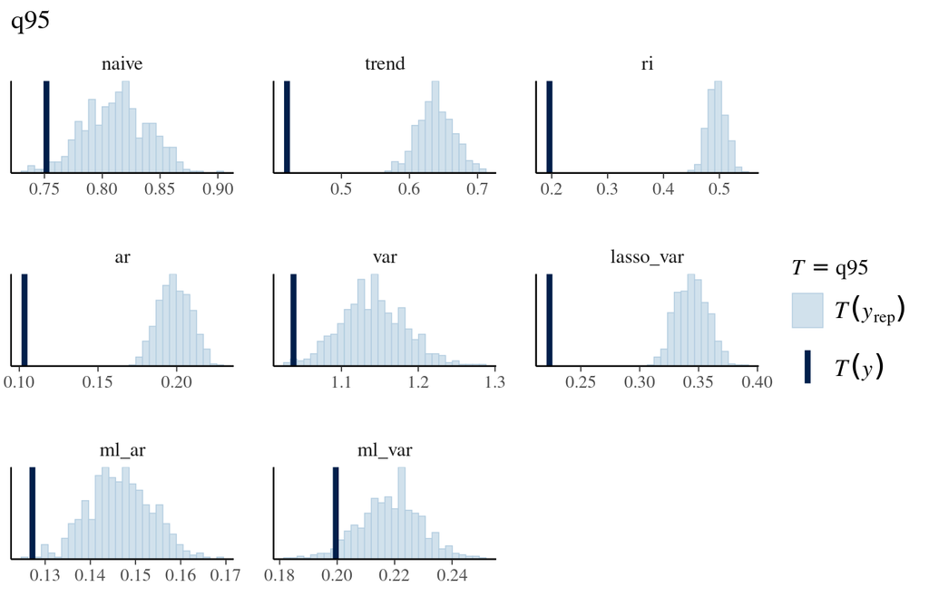

```r
posterior_checks(fit_relmse_s1, log_y = TRUE)
```